# Analysis of First Pass Reading Times

Henrik Singmann

17 October, 2017

```r
require(dplyr)
require(tidyr)
require(stringr)
require(ggplot2)
require(afex)
require(lattice) # for qqmath
require(gridExtra)
library(ggthemes)
theme_set(theme_light())
```

# Data Preparation

```r
data_in <- read.csv("FPs_plus_ratings.csv")
data_in$P.s <- factor(data_in$P.s)
data_in$Item <- factor(data_in$Item)
drp_r <- droplevels(data_in[data_in$Item != "9" ,])
nas <- is.na(drp_r$spillover) | is.na(drp_r$Consequent)
drp_r <- droplevels(drp_r[!nas,])
```

For the analysis we remove 12 trials with missing data in either spillover or Consequent. Then we transform all RTs from ms to s and calculate transformed versions using either `log` or the inverse transformation. We also z-transform the continuous `Accepts` variable.

```r
drp_r <- drp_r %>%
  mutate(
    antecedent = Antecedent/1000,
    log_ant = log(antecedent),
    inv_ant = 1/antecedent,
    consequent = Consequent/1000,
    log_con = log(consequent),
    inv_con = 1/consequent,
    spillover = spillover/1000,
    log_spill = log(spillover),
    inv_spill = 1/spillover,
    acc_z = (Accepts - mean(Accepts))/sd(Accepts),
    #conf_z = (Confident- mean(Confident))/sd(Confident),
    log_acc= log(Accepts))
```

We then plot the three versions of the DVs.

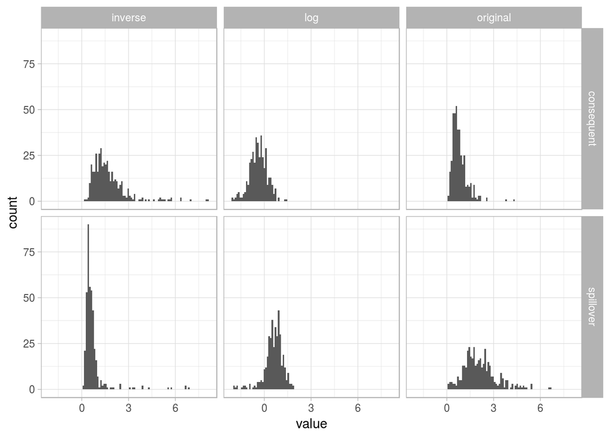

```r
dplot <- drp_r %>%
  gather("key", "value",consequent:inv_spill, spillover) %>%
  mutate(region = if_else(str_detect(key, "spill"), "spillover", "consequent"),
         type = if_else(str_detect(key, "^log"), "log",
                        if_else(str_detect(key, "^inv"), "inverse", "original")))

ggplot(data = dplot) +
  geom_histogram(mapping = aes(x = value), bins = 100) +
  facet_grid(region ~ type)
```

As can be seen, the log transformation helps quite a bit in achieving approximate normality for the consequent DV, but less for the spillover DV. For the `spillover` variable the untransformed DV may work better. For the untransformed values there are quite a few DVs above 5 seconds (consequent = 0, spillover = 0.02), above 3 seconds (consequent = 0.01, spillover = 0.16) or above 2.5 seconds (consequent = 0.01, spillover = 0.29).

# Descriptive Plots

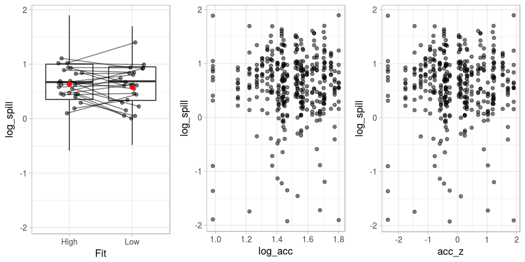

```r
drd_a2 <- drp_r %>%
  group_by(P.s, Fit) %>%
  summarise(log_spill = mean(log_spill))

drp_r$Fit2 <- jitter(as.numeric(drp_r$Fit))
drd_a2$Fit2 <- jitter(as.numeric(drd_a2$Fit))

pres_rp_a <- ggplot(data = drp_r, mapping = aes(x = Fit, y = log_spill)) +
  geom_boxplot(outlier.color =  NA) +
  geom_line(data = drd_a2, aes(x=Fit2, y=log_spill, group = P.s), alpha = 0.5) +
  geom_point(data = drd_a2, aes(x=Fit2, y=log_spill, group = P.s), alpha = 0.5) +
  stat_summary(fun.y = "mean", colour = "red", size = 2, geom = "point")

pres_rp_b <- ggplot(data = drp_r, mapping = aes(x = log_acc, y = log_spill)) +
  geom_point(alpha = 0.5)

pres_rp_c <- ggplot(data = drp_r, mapping = aes(x = acc_z, y = log_spill)) +
  geom_point(alpha = 0.5)

grid.arrange(pres_rp_a, pres_rp_b, pres_rp_c, ncol = 3)
```

# Consequent

Note that the maximal model for models including `Fit` have random slopes for `Fit` for both random effects grouping factors (i.e., participant `P.s` and `Item`). For models including the continuous fit measure `Accepts` we have by-participant random slopes for `Accepts`, but by-item random slopes for `Fit` (as `Accepts` has only two different values for each `Item`, using the binary `Fit` variable seems more reasonable.)

## With Fit (log-transformed RTs)

```r
m_fp_con_1 <- mixed(log_con ~ Fit + (Fit|P.s) + (Fit| Item), drp_r, progress = FALSE)
```

```
## Contrasts set to contr.sum for the following variables: Fit, P.s, Item
```

```
## Note: method with signature 'sparseMatrix#ANY' chosen for function 'kronecker',
##  target signature 'dgCMatrix#ngCMatrix'.
##  "ANY#sparseMatrix" would also be valid
```

```r
summary(m_fp_con_1)
```

```
## Linear mixed model fit by REML ['merModLmerTest']
## Formula: log_con ~ Fit + (Fit | P.s) + (Fit | Item)
##    Data: drp_r
##
## REML criterion at convergence: 602.1
##
## Scaled residuals:
##     Min      1Q  Median      3Q     Max
## -3.9568 -0.4855  0.0329  0.5999  3.8295
##
## Random effects:
##  Groups   Name        Variance  Std.Dev. Corr
##  P.s      (Intercept) 0.0488130 0.2209
##           Fit1        0.0003801 0.0195   1.00
##  Item     (Intercept) 0.0501493 0.2239
##           Fit1        0.0003167 0.0178   -1.00
##  Residual             0.2221539 0.4713
## Number of obs: 396, groups:  P.s, 24; Item, 17
##
## Fixed effects:
##             Estimate Std. Error t value
## (Intercept) -0.37649    0.07448  -5.055
## Fit1        -0.01308    0.02445  -0.535
##
## Correlation of Fixed Effects:
##      (Intr)
## Fit1 -0.027
```

Due to the extreme correlations between the by-participant and by-item intercept and slopes we refit the model without the correlations.

```r
m_fp_con_2 <- mixed(log_con ~ Fit + (Fit||P.s) + (Fit|| Item), drp_r, expand_re = TRUE, progress = FALSE)
```

```
## Contrasts set to contr.sum for the following variables: Fit, P.s, Item
```

```r
summary(m_fp_con_2)
```

```
## Linear mixed model fit by REML ['merModLmerTest']
## Formula:
## log_con ~ Fit + ((1 | P.s) + (0 + re1.Fit1 | P.s)) + ((1 | Item) +
##     (0 + re2.Fit1 | Item))
##    Data: drp_r
##
## REML criterion at convergence: 603
##
## Scaled residuals:
##     Min      1Q  Median      3Q     Max
## -3.9507 -0.4789  0.0164  0.6243  3.8247
##
## Random effects:
##  Groups   Name        Variance Std.Dev.
##  P.s      (Intercept) 0.04834  0.2199
##  P.s.1    re1.Fit1    0.00000  0.0000
##  Item     (Intercept) 0.05056  0.2249
##  Item.1   re2.Fit1    0.00000  0.0000
##  Residual             0.22290  0.4721
## Number of obs: 396, groups:  P.s, 24; Item, 17
##
## Fixed effects:
##             Estimate Std. Error t value
## (Intercept) -0.37625    0.07452  -5.049
## Fit1        -0.01302    0.02377  -0.548
##
## Correlation of Fixed Effects:
##      (Intr)
## Fit1 0.003
```

Now the `Fit` random slopes show no variability so we consequently refit the model without that parameter.

```r
m_fp_con_3 <- mixed(log_con ~ Fit + (1|P.s) + (1| Item), drp_r, progress = FALSE)
```

```
## Contrasts set to contr.sum for the following variables: Fit, P.s, Item
```

```r
summary(m_fp_con_3)
```

```
## Linear mixed model fit by REML ['merModLmerTest']
## Formula: log_con ~ Fit + (1 | P.s) + (1 | Item)
##    Data: drp_r
##
## REML criterion at convergence: 603
##
## Scaled residuals:
##     Min      1Q  Median      3Q     Max
## -3.9507 -0.4789  0.0164  0.6243  3.8247
##
## Random effects:
##  Groups   Name        Variance Std.Dev.
##  P.s      (Intercept) 0.04834  0.2199
##  Item     (Intercept) 0.05056  0.2249
##  Residual             0.22290  0.4721
## Number of obs: 396, groups:  P.s, 24; Item, 17
##
## Fixed effects:
##             Estimate Std. Error t value
## (Intercept) -0.37625    0.07452  -5.049
## Fit1        -0.01302    0.02377  -0.548
##
## Correlation of Fixed Effects:
##      (Intr)
## Fit1 0.003
```

This model seems reasonable and only provides a minimally worse account than the first model.

```r
anova(m_fp_con_1, m_fp_con_3)
```

```
## Data: drp_r
## Models:
## m_fp_con_3: log_con ~ Fit + (1 | P.s) + (1 | Item)
## m_fp_con_1: log_con ~ Fit + (Fit | P.s) + (Fit | Item)
##            Df    AIC    BIC  logLik deviance  Chisq Chi Df Pr(>Chisq)
## m_fp_con_3  5 613.02 632.93 -301.51   603.02
## m_fp_con_1  9 620.09 655.92 -301.05   602.09 0.9329      4     0.9198
```

However, the QQ-plot of both models shows relatively strong misfit for short RTs and somewhat less for long RTs. Significant outliers (i.e., observations with absolute standardized/normalized residuals greater than the .995 quantile of the standard normal distribution) are identified by the number of the participant providing this response.

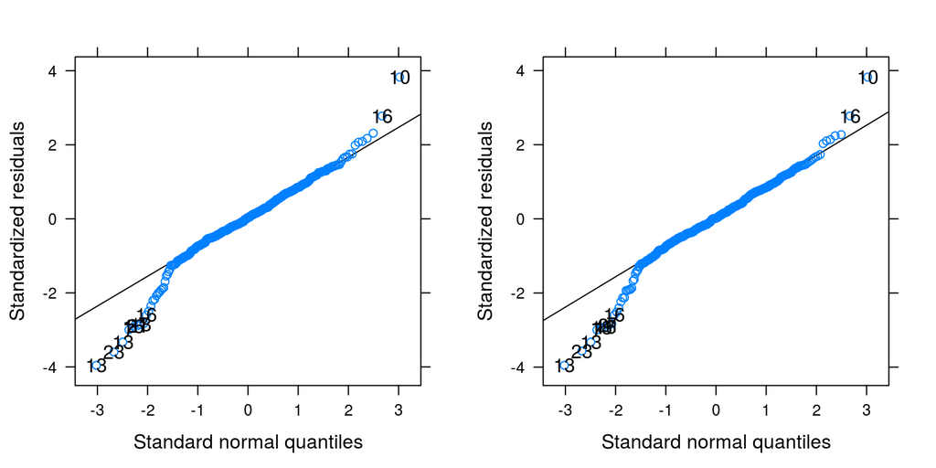

```r
qqp_m1 <- qqmath(m_fp_con_1$full_model, id = 0.01, idLabels = as.character(drp_r$P.s))
qqp_m2 <- qqmath(m_fp_con_3$full_model, id = 0.01, idLabels = as.character(drp_r$P.s))
grid.arrange(qqp_m1, qqp_m2, ncol = 2)
```

The effect of `Fit` is not significant for both models.

```r
nice(m_fp_con_1)
```

```
## Mixed Model Anova Table (Type 3 tests, KR-method)
##
## Model: log_con ~ Fit + (Fit | P.s) + (Fit | Item)
## Data: drp_r
##   Effect      df    F p.value
## 1    Fit 1, 9.22 0.29     .61
## ---
## Signif. codes:  0 '***' 0.001 '**' 0.01 '*' 0.05 '+' 0.1 ' ' 1
```

```r
nice(m_fp_con_3)
```

```
## Mixed Model Anova Table (Type 3 tests, KR-method)
##
## Model: log_con ~ Fit + (1 | P.s) + (1 | Item)
## Data: drp_r
##   Effect        df    F p.value
## 1    Fit 1, 355.67 0.30     .58
## ---
## Signif. codes:  0 '***' 0.001 '**' 0.01 '*' 0.05 '+' 0.1 ' ' 1
```

## With Fit (untransformed RTs)

```r
m_con_u_1 <- mixed(consequent ~ Fit + (Fit|P.s) + (Fit| Item), drp_r, progress = FALSE)
```

```
## Contrasts set to contr.sum for the following variables: Fit, P.s, Item
```

```r
summary(m_con_u_1)
```

```
## Linear mixed model fit by REML ['merModLmerTest']
## Formula: consequent ~ Fit + (Fit | P.s) + (Fit | Item)
##    Data: drp_r
##
## REML criterion at convergence: 493.9
##
## Scaled residuals:
##     Min      1Q  Median      3Q     Max
## -2.7448 -0.4927 -0.1506  0.3765  8.2477
##
## Random effects:
##  Groups   Name        Variance  Std.Dev. Corr
##  P.s      (Intercept) 3.660e-02 0.19132
##           Fit1        1.296e-05 0.00360  1.00
##  Item     (Intercept) 3.258e-02 0.18051
##           Fit1        4.601e-04 0.02145  -1.00
##  Residual             1.699e-01 0.41221
## Number of obs: 396, groups:  P.s, 24; Item, 17
##
## Fixed effects:
##             Estimate Std. Error t value
## (Intercept)  0.80251    0.06223  12.896
## Fit1        -0.01298    0.02141  -0.606
##
## Correlation of Fixed Effects:
##      (Intr)
## Fit1 -0.146
```

Due to the extreme correlations between the by-participant and by-item intercept and slopes we refit the model without the correlations.

```r
m_con_u_2 <- mixed(consequent ~ Fit + (Fit||P.s) + (Fit|| Item), drp_r,
                   progress = FALSE, expand_re = TRUE)
```

```
## Contrasts set to contr.sum for the following variables: Fit, P.s, Item
```

```r
summary(m_con_u_2)
```

```
## Linear mixed model fit by REML ['merModLmerTest']
## Formula: consequent ~ Fit + ((1 | P.s) + (0 + re1.Fit1 | P.s)) + ((1 |
##     Item) + (0 + re2.Fit1 | Item))
##    Data: drp_r
##
## REML criterion at convergence: 494.8
##
## Scaled residuals:
##     Min      1Q  Median      3Q     Max
## -2.7639 -0.4828 -0.1515  0.3827  8.2009
##
## Random effects:
##  Groups   Name        Variance Std.Dev.
##  P.s      (Intercept) 0.03606  0.1899
##  P.s.1    re1.Fit1    0.00000  0.0000
##  Item     (Intercept) 0.03280  0.1811
##  Item.1   re2.Fit1    0.00000  0.0000
##  Residual             0.17050  0.4129
## Number of obs: 396, groups:  P.s, 24; Item, 17
##
## Fixed effects:
##             Estimate Std. Error t value
## (Intercept)  0.80237    0.06216   12.91
## Fit1        -0.01268    0.02079   -0.61
##
## Correlation of Fixed Effects:
##      (Intr)
## Fit1 0.003
```

Now the `Fit` random slopes show no variability so we consequently refit the model without that parameter.

```r
m_con_u_3 <- mixed(consequent ~ Fit + (1|P.s) + (1| Item), drp_r, progress = FALSE)
```

```
## Contrasts set to contr.sum for the following variables: Fit, P.s, Item
```

```r
summary(m_con_u_3)
```

```
## Linear mixed model fit by REML ['merModLmerTest']
## Formula: consequent ~ Fit + (1 | P.s) + (1 | Item)
##    Data: drp_r
##
## REML criterion at convergence: 494.8
##
## Scaled residuals:
##     Min      1Q  Median      3Q     Max
## -2.7639 -0.4828 -0.1515  0.3827  8.2009
##
## Random effects:
##  Groups   Name        Variance Std.Dev.
##  P.s      (Intercept) 0.03606  0.1899
##  Item     (Intercept) 0.03280  0.1811
##  Residual             0.17050  0.4129
## Number of obs: 396, groups:  P.s, 24; Item, 17
##
## Fixed effects:
##             Estimate Std. Error t value
## (Intercept)  0.80237    0.06216   12.91
## Fit1        -0.01268    0.02079   -0.61
##
## Correlation of Fixed Effects:
##      (Intr)
## Fit1 0.003
```

This model seems reasonable and only provides a minimally worse account than the first model.

```r
anova(m_con_u_1, m_con_u_2, m_con_u_3)
```

```
## Data: drp_r
## Models:
## m_con_u_3: consequent ~ Fit + (1 | P.s) + (1 | Item)
## m_con_u_2: consequent ~ Fit + ((1 | P.s) + (0 + re1.Fit1 | P.s)) + ((1 |
## m_con_u_2:     Item) + (0 + re2.Fit1 | Item))
## m_con_u_1: consequent ~ Fit + (Fit | P.s) + (Fit | Item)
##           Df    AIC    BIC  logLik deviance  Chisq Chi Df Pr(>Chisq)
## m_con_u_3  5 504.81 524.72 -247.41   494.81
## m_con_u_2  7 508.81 536.68 -247.41   494.81 0.0000      2     1.0000
## m_con_u_1  9 511.94 547.78 -246.97   493.94 0.8683      2     0.6478
```

However, the QQ-plot now shows the perhaps expected misfit for long RTs.

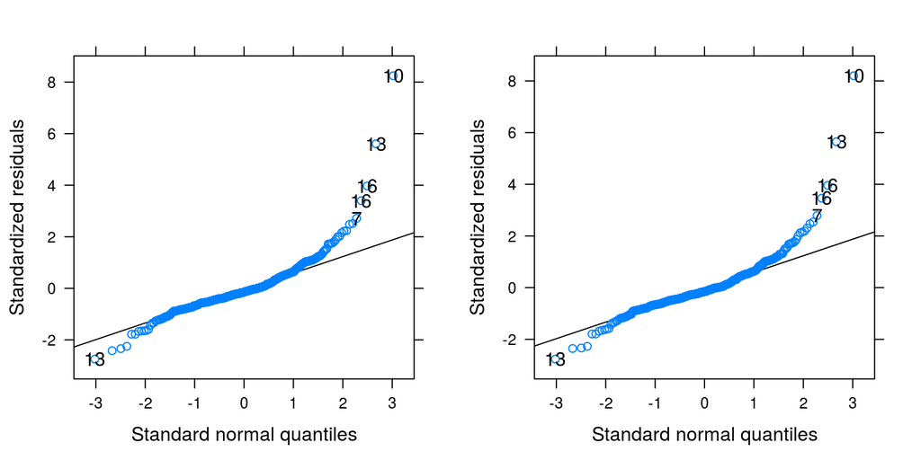

```r
qqp_m1 <- qqmath(m_con_u_1$full_model, id = 0.01, idLabels = as.character(drp_r$P.s))
qqp_m2 <- qqmath(m_con_u_3$full_model, id = 0.01, idLabels = as.character(drp_r$P.s))
grid.arrange(qqp_m1, qqp_m2, ncol = 2)
```

Again, the effect of `Fit` is not significant.

```r
nice(m_con_u_1)
```

```
## Mixed Model Anova Table (Type 3 tests, KR-method)
##
## Model: consequent ~ Fit + (Fit | P.s) + (Fit | Item)
## Data: drp_r
##   Effect      df    F p.value
## 1    Fit 1, 9.14 0.37     .56
## ---
## Signif. codes:  0 '***' 0.001 '**' 0.01 '*' 0.05 '+' 0.1 ' ' 1
```

```r
nice(m_con_u_3)
```

```
## Mixed Model Anova Table (Type 3 tests, KR-method)
##
## Model: consequent ~ Fit + (1 | P.s) + (1 | Item)
## Data: drp_r
##   Effect        df    F p.value
## 1    Fit 1, 355.71 0.37     .54
## ---
## Signif. codes:  0 '***' 0.001 '**' 0.01 '*' 0.05 '+' 0.1 ' ' 1
```

## With Fit (Lambert transformation)

To address the remaining misfit I try a more drastic approach. First we remove a few (4) RTs above 2.5 seconds. Then we apply the Lambert transformation to normalize the data (following Goerg, 2011).

```r
drp_r_r1 <- drp_r[drp_r$consequent < 2.5,]
drp_r_r1$consequentw <- as.vector(LambertW::Gaussianize(drp_r_r1$consequent,
                                                        type = "h", method = "MLE"))
```

```r
m_con_lamb_1 <- mixed(consequentw ~ Fit + (Fit|P.s) + (Fit| Item), drp_r_r1, progress = FALSE)
```

```
## Contrasts set to contr.sum for the following variables: Fit, P.s, Item
```

```r
summary(m_con_lamb_1)
```

```
## Linear mixed model fit by REML ['merModLmerTest']
## Formula: consequentw ~ Fit + (Fit | P.s) + (Fit | Item)
##    Data: drp_r_r1
##
## REML criterion at convergence: 162.8
##
## Scaled residuals:
##     Min      1Q  Median      3Q     Max
## -3.4264 -0.5927 -0.1227  0.5921  2.8068
##
## Random effects:
##  Groups   Name        Variance  Std.Dev. Corr
##  P.s      (Intercept) 2.314e-02 0.152111
##           Fit1        2.973e-04 0.017242 1.00
##  Item     (Intercept) 1.998e-02 0.141349
##           Fit1        4.121e-05 0.006419 -1.00
##  Residual             7.117e-02 0.266772
## Number of obs: 392, groups:  P.s, 24; Item, 17
##
## Fixed effects:
##              Estimate Std. Error t value
## (Intercept)  0.751827   0.048187   15.60
## Fit1        -0.006596   0.014044   -0.47
##
## Correlation of Fixed Effects:
##      (Intr)
## Fit1 0.084
```

We again remove the correlation parameters due to the extreme estimates.

```r
m_con_lamb_2 <- mixed(consequentw ~ Fit + (Fit||P.s) + (Fit || Item), drp_r_r1,
                      progress = FALSE, expand_re = TRUE)
```

```
## Contrasts set to contr.sum for the following variables: Fit, P.s, Item
```

```r
summary(m_con_lamb_2)
```

```
## Linear mixed model fit by REML ['merModLmerTest']
## Formula: consequentw ~ Fit + ((1 | P.s) + (0 + re1.Fit1 | P.s)) + ((1 |
##     Item) + (0 + re2.Fit1 | Item))
##    Data: drp_r_r1
##
## REML criterion at convergence: 164.2
##
## Scaled residuals:
##     Min      1Q  Median      3Q     Max
## -3.3672 -0.5996 -0.1333  0.6180  2.8931
##
## Random effects:
##  Groups   Name        Variance  Std.Dev.
##  P.s      (Intercept) 0.0230593 0.15185
##  P.s.1    re1.Fit1    0.0001572 0.01254
##  Item     (Intercept) 0.0201648 0.14200
##  Item.1   re2.Fit1    0.0000000 0.00000
##  Residual             0.0713316 0.26708
## Number of obs: 392, groups:  P.s, 24; Item, 17
##
## Fixed effects:
##              Estimate Std. Error t value
## (Intercept)  0.751930   0.048272  15.577
## Fit1        -0.006564   0.013765  -0.477
##
## Correlation of Fixed Effects:
##      (Intr)
## Fit1 0.001
```

Now the by-item `Fit` random slope is estimated at 0 and we remove it.

```r
m_con_lamb_3 <- mixed(consequentw ~ Fit + (Fit||P.s) + (1| Item), drp_r_r1,
                      progress = FALSE, expand_re = TRUE)
```

```
## Contrasts set to contr.sum for the following variables: Fit, P.s, Item
```

```r
summary(m_con_lamb_3)
```

```
## Linear mixed model fit by REML ['merModLmerTest']
## Formula: consequentw ~ Fit + ((1 | P.s) + (0 + re1.Fit1 | P.s)) + (1 |
##     Item)
##    Data: drp_r_r1
##
## REML criterion at convergence: 164.2
##
## Scaled residuals:
##     Min      1Q  Median      3Q     Max
## -3.3672 -0.5996 -0.1333  0.6180  2.8931
##
## Random effects:
##  Groups   Name        Variance  Std.Dev.
##  P.s      (Intercept) 0.0230593 0.15185
##  P.s.1    re1.Fit1    0.0001572 0.01254
##  Item     (Intercept) 0.0201648 0.14200
##  Residual             0.0713316 0.26708
## Number of obs: 392, groups:  P.s, 24; Item, 17
##
## Fixed effects:
##              Estimate Std. Error t value
## (Intercept)  0.751930   0.048272  15.577
## Fit1        -0.006564   0.013765  -0.477
##
## Correlation of Fixed Effects:
##      (Intr)
## Fit1 0.001
```

The most reduced model again provides the best account.

```r
anova(m_con_lamb_1, m_con_lamb_2, m_con_lamb_3)
```

```
## Data: drp_r_r1
## Models:
## m_con_lamb_3: consequentw ~ Fit + ((1 | P.s) + (0 + re1.Fit1 | P.s)) + (1 |
## m_con_lamb_3:     Item)
## m_con_lamb_2: consequentw ~ Fit + ((1 | P.s) + (0 + re1.Fit1 | P.s)) + ((1 |
## m_con_lamb_2:     Item) + (0 + re2.Fit1 | Item))
## m_con_lamb_1: consequentw ~ Fit + (Fit | P.s) + (Fit | Item)
##              Df    AIC    BIC  logLik deviance  Chisq Chi Df Pr(>Chisq)
## m_con_lamb_3  6 176.18 200.00 -82.088   164.18
## m_con_lamb_2  7 178.18 205.98 -82.088   164.18 0.0000      1     1.0000
## m_con_lamb_1  9 180.78 216.52 -81.389   162.78 1.3987      2     0.4969
```

Now the QQ-plot shows only mild violations of normality.

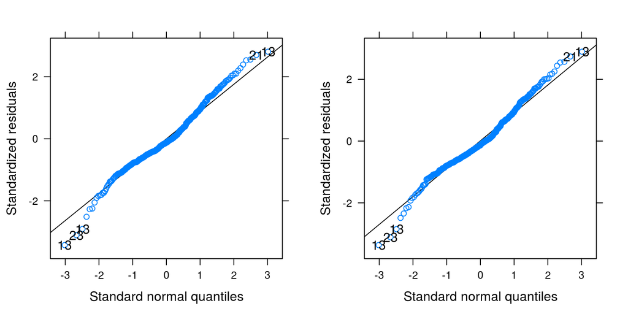

```r
qqp_m1 <- qqmath(m_con_lamb_1$full_model, id = 0.01, idLabels = as.character(drp_r_r1$P.s))
qqp_m2 <- qqmath(m_con_lamb_3$full_model, id = 0.01, idLabels = as.character(drp_r_r1$P.s))
grid.arrange(qqp_m1, qqp_m2, ncol = 2)
```

However, the effect of `Fit` is still not significant.

```r
nice(m_con_lamb_1)
```

```
## Mixed Model Anova Table (Type 3 tests, KR-method)
##
## Model: consequentw ~ Fit + (Fit | P.s) + (Fit | Item)
## Data: drp_r_r1
##   Effect      df    F p.value
## 1    Fit 1, 9.46 0.22     .65
## ---
## Signif. codes:  0 '***' 0.001 '**' 0.01 '*' 0.05 '+' 0.1 ' ' 1
```

```r
nice(m_con_lamb_1)
```

```
## Mixed Model Anova Table (Type 3 tests, KR-method)
##
## Model: consequentw ~ Fit + (Fit | P.s) + (Fit | Item)
## Data: drp_r_r1
##   Effect      df    F p.value
## 1    Fit 1, 9.46 0.22     .65
## ---
## Signif. codes:  0 '***' 0.001 '**' 0.01 '*' 0.05 '+' 0.1 ' ' 1
```

## With Accepts (log-transformed RT and Accepts)

```r
m_fp_con_11 <- mixed(log_con ~ log_acc + (log_acc|P.s) + (Fit| Item), drp_r, progress = FALSE)
```

```
## Contrasts set to contr.sum for the following variables: P.s, Fit, Item
```

```
## Numerical variables NOT centered on 0 (i.e., interpretation of all main effects might be difficult if in interactions): log_acc
```

```r
summary(m_fp_con_11)
```

```
## Linear mixed model fit by REML ['merModLmerTest']
## Formula: log_con ~ log_acc + (log_acc | P.s) + (Fit | Item)
##    Data: drp_r
##
## REML criterion at convergence: 598.3
##
## Scaled residuals:
##     Min      1Q  Median      3Q     Max
## -3.9653 -0.4869  0.0351  0.5889  3.8320
##
## Random effects:
##  Groups   Name        Variance Std.Dev. Corr
##  P.s      (Intercept) 0.011799 0.10862
##           log_acc     0.005572 0.07464  1.00
##  Item     (Intercept) 0.050813 0.22542
##           Fit1        0.000413 0.02032  -1.00
##  Residual             0.222076 0.47125
## Number of obs: 396, groups:  P.s, 24; Item, 17
##
## Fixed effects:
##             Estimate Std. Error t value
## (Intercept)  -0.2077     0.2519  -0.825
## log_acc      -0.1120     0.1577  -0.710
##
## Correlation of Fixed Effects:
##         (Intr)
## log_acc -0.956
```

As for the binary variable we see a extreme correlations between the random-effects parameters for both random-effects.

```r
m_fp_con_12 <- mixed(log_con ~ log_acc + (log_acc||P.s) + (Fit||Item), drp_r, expand_re = TRUE, progress = FALSE)
```

```
## Contrasts set to contr.sum for the following variables: P.s, Fit, Item
```

```
## Numerical variables NOT centered on 0 (i.e., interpretation of all main effects might be difficult if in interactions): log_acc
```

```r
summary(m_fp_con_12)
```

```
## Linear mixed model fit by REML ['merModLmerTest']
## Formula:
## log_con ~ log_acc + ((1 | P.s) + (0 + re1.log_acc | P.s)) + ((1 |
##     Item) + (0 + re2.Fit1 | Item))
##    Data: drp_r
##
## REML criterion at convergence: 599.1
##
## Scaled residuals:
##     Min      1Q  Median      3Q     Max
## -3.9842 -0.4730  0.0251  0.6063  3.8127
##
## Random effects:
##  Groups   Name        Variance Std.Dev.
##  P.s      (Intercept) 0.028540 0.16894
##  P.s.1    re1.log_acc 0.008553 0.09248
##  Item     (Intercept) 0.050926 0.22567
##  Item.1   re2.Fit1    0.000000 0.00000
##  Residual             0.222655 0.47186
## Number of obs: 396, groups:  P.s, 24; Item, 17
##
## Fixed effects:
##             Estimate Std. Error t value
## (Intercept) -0.23056    0.24065  -0.958
## log_acc     -0.09733    0.15516  -0.627
##
## Correlation of Fixed Effects:
##         (Intr)
## log_acc -0.951
```

Because the by-item random slope is zero we remove it.

```r
m_fp_con_13 <- mixed(log_con ~ log_acc + (log_acc||P.s) + (1|Item), drp_r, expand_re = TRUE, progress = FALSE)
```

```
## Contrasts set to contr.sum for the following variables: P.s, Item
```

```
## Numerical variables NOT centered on 0 (i.e., interpretation of all main effects might be difficult if in interactions): log_acc
```

```r
summary(m_fp_con_13)
```

```
## Linear mixed model fit by REML ['merModLmerTest']
## Formula: log_con ~ log_acc + ((1 | P.s) + (0 + re1.log_acc | P.s)) + (1 |
##     Item)
##    Data: drp_r
##
## REML criterion at convergence: 599.1
##
## Scaled residuals:
##     Min      1Q  Median      3Q     Max
## -3.9842 -0.4730  0.0251  0.6063  3.8127
##
## Random effects:
##  Groups   Name        Variance Std.Dev.
##  P.s      (Intercept) 0.028539 0.16894
##  P.s.1    re1.log_acc 0.008553 0.09248
##  Item     (Intercept) 0.050926 0.22567
##  Residual             0.222655 0.47186
## Number of obs: 396, groups:  P.s, 24; Item, 17
##
## Fixed effects:
##             Estimate Std. Error t value
## (Intercept) -0.23056    0.24065  -0.958
## log_acc     -0.09733    0.15516  -0.627
##
## Correlation of Fixed Effects:
##         (Intr)
## log_acc -0.951
```

```r
anova(m_fp_con_11, m_fp_con_12, m_fp_con_13)
```

```
## Data: drp_r
## Models:
## m_fp_con_13: log_con ~ log_acc + ((1 | P.s) + (0 + re1.log_acc | P.s)) + (1 |
## m_fp_con_13:     Item)
## m_fp_con_12: log_con ~ log_acc + ((1 | P.s) + (0 + re1.log_acc | P.s)) + ((1 |
## m_fp_con_12:     Item) + (0 + re2.Fit1 | Item))
## m_fp_con_11: log_con ~ log_acc + (log_acc | P.s) + (Fit | Item)
##             Df    AIC    BIC  logLik deviance  Chisq Chi Df Pr(>Chisq)
## m_fp_con_13  6 611.08 634.97 -299.54   599.08
## m_fp_con_12  7 613.08 640.95 -299.54   599.08 0.0000      1     1.0000
## m_fp_con_11  9 616.31 652.14 -299.15   598.31 0.7711      2     0.6801
```

The most reduced model seems to provide the best account. However, we see strong deviations from normality for fast RTs.

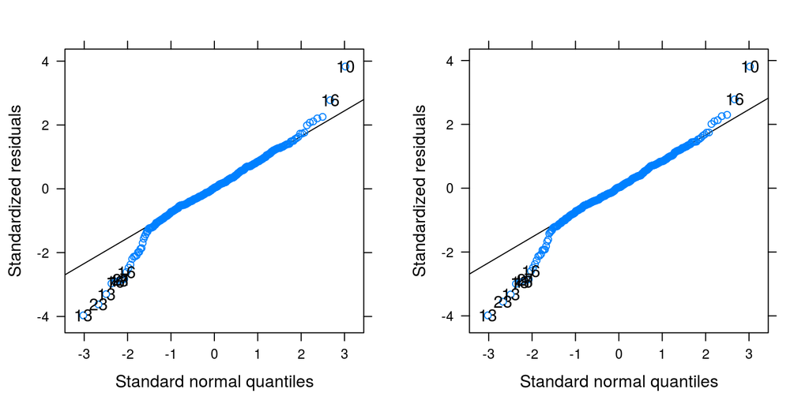

```r
qqp_11 <- qqmath(m_fp_con_11$full_model, id = 0.01, idLabels = as.character(drp_r$P.s))
qqp_12 <- qqmath(m_fp_con_13$full_model, id = 0.01, idLabels = as.character(drp_r$P.s))
grid.arrange(qqp_11, qqp_12, ncol = 2)
```

Again, neither model shows a significant effect of `log_acc`.

```r
nice(m_fp_con_11)
```

```
## Mixed Model Anova Table (Type 3 tests, KR-method)
##
## Model: log_con ~ log_acc + (log_acc | P.s) + (Fit | Item)
## Data: drp_r
##    Effect       df    F p.value
## 1 log_acc 1, 12.58 0.46     .51
## ---
## Signif. codes:  0 '***' 0.001 '**' 0.01 '*' 0.05 '+' 0.1 ' ' 1
```

```r
nice(m_fp_con_12)
```

```
## Mixed Model Anova Table (Type 3 tests, KR-method)
##
## Model: log_con ~ log_acc + (log_acc || P.s) + (Fit || Item)
## Data: drp_r
##    Effect       df    F p.value
## 1 log_acc 1, 17.40 0.38     .55
## ---
## Signif. codes:  0 '***' 0.001 '**' 0.01 '*' 0.05 '+' 0.1 ' ' 1
```

## With Accepts (log-transformed RTs)

```r
m_fp_con_21 <- mixed(log_con ~ acc_z + (acc_z|P.s) + (Fit| Item), drp_r, progress = FALSE)
```

```
## Contrasts set to contr.sum for the following variables: P.s, Fit, Item
```

```r
summary(m_fp_con_21)
```

```
## Linear mixed model fit by REML ['merModLmerTest']
## Formula: log_con ~ acc_z + (acc_z | P.s) + (Fit | Item)
##    Data: drp_r
##
## REML criterion at convergence: 601.5
##
## Scaled residuals:
##     Min      1Q  Median      3Q     Max
## -3.9697 -0.4829  0.0309  0.6003  3.8365
##
## Random effects:
##  Groups   Name        Variance  Std.Dev. Corr
##  P.s      (Intercept) 0.0484595 0.22014
##           acc_z       0.0002735 0.01654  1.00
##  Item     (Intercept) 0.0505504 0.22483
##           Fit1        0.0004422 0.02103  -1.00
##  Residual             0.2219747 0.47114
## Number of obs: 396, groups:  P.s, 24; Item, 17
##
## Fixed effects:
##             Estimate Std. Error t value
## (Intercept) -0.37442    0.07427  -5.042
## acc_z       -0.02233    0.02856  -0.782
##
## Correlation of Fixed Effects:
##       (Intr)
## acc_z -0.053
```

We remove the correlations among the random effects.

```r
m_fp_con_22 <- mixed(log_con ~ acc_z + (acc_z||P.s) + (Fit||Item), drp_r, expand_re = TRUE, progress = FALSE)
```

```
## Contrasts set to contr.sum for the following variables: P.s, Fit, Item
```

```r
summary(m_fp_con_22)
```

```
## Linear mixed model fit by REML ['merModLmerTest']
## Formula: log_con ~ acc_z + ((1 | P.s) + (0 + re1.acc_z | P.s)) + ((1 |
##     Item) + (0 + re2.Fit1 | Item))
##    Data: drp_r
##
## REML criterion at convergence: 602.5
##
## Scaled residuals:
##     Min      1Q  Median      3Q     Max
## -3.9493 -0.4734  0.0236  0.6074  3.8183
##
## Random effects:
##  Groups   Name        Variance Std.Dev.
##  P.s      (Intercept) 0.04814  0.2194
##  P.s.1    re1.acc_z   0.00000  0.0000
##  Item     (Intercept) 0.05081  0.2254
##  Item.1   re2.Fit1    0.00000  0.0000
##  Residual             0.22276  0.4720
## Number of obs: 396, groups:  P.s, 24; Item, 17
##
## Fixed effects:
##             Estimate Std. Error t value
## (Intercept) -0.37620    0.07456  -5.045
## acc_z       -0.02035    0.02797  -0.728
##
## Correlation of Fixed Effects:
##       (Intr)
## acc_z 0.001
```

We remove the random slopes.

```r
m_fp_con_23 <- mixed(log_con ~ acc_z + (1|P.s) + (1|Item), drp_r, expand_re = FALSE, progress = FALSE)
```

```
## Contrasts set to contr.sum for the following variables: P.s, Item
```

```r
summary(m_fp_con_23)
```

```
## Linear mixed model fit by REML ['merModLmerTest']
## Formula: log_con ~ acc_z + (1 | P.s) + (1 | Item)
##    Data: drp_r
##
## REML criterion at convergence: 602.5
##
## Scaled residuals:
##     Min      1Q  Median      3Q     Max
## -3.9493 -0.4734  0.0236  0.6074  3.8183
##
## Random effects:
##  Groups   Name        Variance Std.Dev.
##  P.s      (Intercept) 0.04814  0.2194
##  Item     (Intercept) 0.05081  0.2254
##  Residual             0.22276  0.4720
## Number of obs: 396, groups:  P.s, 24; Item, 17
##
## Fixed effects:
##             Estimate Std. Error t value
## (Intercept) -0.37620    0.07456  -5.045
## acc_z       -0.02035    0.02797  -0.728
##
## Correlation of Fixed Effects:
##       (Intr)
## acc_z 0.001
```

```r
anova(m_fp_con_21, m_fp_con_22, m_fp_con_23)
```

```
## Data: drp_r
## Models:
## m_fp_con_23: log_con ~ acc_z + (1 | P.s) + (1 | Item)
## m_fp_con_22: log_con ~ acc_z + ((1 | P.s) + (0 + re1.acc_z | P.s)) + ((1 |
## m_fp_con_22:     Item) + (0 + re2.Fit1 | Item))
## m_fp_con_21: log_con ~ acc_z + (acc_z | P.s) + (Fit | Item)
##             Df    AIC    BIC  logLik deviance  Chisq Chi Df Pr(>Chisq)
## m_fp_con_23  5 612.47 632.38 -301.24   602.47
## m_fp_con_22  7 616.47 644.34 -301.24   602.47 0.0000      2     1.0000
## m_fp_con_21  9 619.49 655.32 -300.74   601.49 0.9818      2     0.6121
```

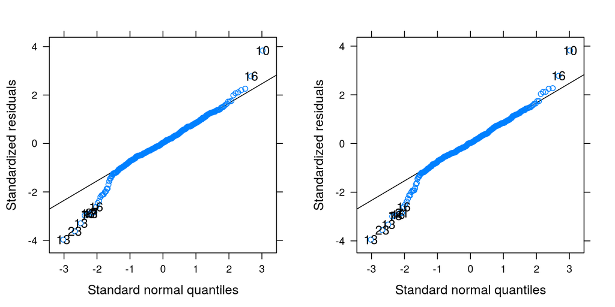

```r
qqp_21 <- qqmath(m_fp_con_21$full_model, id = 0.01, idLabels = as.character(drp_r$P.s))
qqp_22 <- qqmath(m_fp_con_22$full_model, id = 0.01, idLabels = as.character(drp_r$P.s))
grid.arrange(qqp_21, qqp_22, ncol = 2)
```

Furthermore, neither model shows a significant effect of `Accepts` (z-transformed to `acc_z`).

```r
nice(m_fp_con_21)
```

```
## Mixed Model Anova Table (Type 3 tests, KR-method)
##
## Model: log_con ~ acc_z + (acc_z | P.s) + (Fit | Item)
## Data: drp_r
##   Effect       df    F p.value
## 1  acc_z 1, 12.72 0.56     .47
## ---
## Signif. codes:  0 '***' 0.001 '**' 0.01 '*' 0.05 '+' 0.1 ' ' 1
```

```r
nice(m_fp_con_22)
```

```
## Mixed Model Anova Table (Type 3 tests, KR-method)
##
## Model: log_con ~ acc_z + (acc_z || P.s) + (Fit || Item)
## Data: drp_r
##   Effect       df    F p.value
## 1  acc_z 1, 12.04 0.51     .49
## ---
## Signif. codes:  0 '***' 0.001 '**' 0.01 '*' 0.05 '+' 0.1 ' ' 1
```

## With Accepts (Lambert transformed RTs)

```r
m_con_lambert_a_1 <- mixed(consequentw ~ acc_z + (acc_z|P.s) + (Fit| Item), drp_r_r1, progress = FALSE)
```

```
## Contrasts set to contr.sum for the following variables: P.s, Fit, Item
```

```
## Numerical variables NOT centered on 0 (i.e., interpretation of all main effects might be difficult if in interactions): acc_z
```

```r
summary(m_con_lambert_a_1)
```

```
## Linear mixed model fit by REML ['merModLmerTest']
## Formula: consequentw ~ acc_z + (acc_z | P.s) + (Fit | Item)
##    Data: drp_r_r1
##
## REML criterion at convergence: 162.9
##
## Scaled residuals:
##     Min      1Q  Median      3Q     Max
## -3.4410 -0.5935 -0.1274  0.6040  2.8165
##
## Random effects:
##  Groups   Name        Variance  Std.Dev. Corr
##  P.s      (Intercept) 2.305e-02 0.151836
##           acc_z       1.709e-04 0.013071 1.00
##  Item     (Intercept) 2.024e-02 0.142284
##           Fit1        5.892e-05 0.007676 -1.00
##  Residual             7.126e-02 0.266939
## Number of obs: 392, groups:  P.s, 24; Item, 17
##
## Fixed effects:
##              Estimate Std. Error t value
## (Intercept)  0.751796   0.048250  15.581
## acc_z       -0.007432   0.016317  -0.455
##
## Correlation of Fixed Effects:
##       (Intr)
## acc_z 0.025
```

We remove the correlations among the random effects.

```r
m_con_lambert_a_2 <- mixed(consequentw ~ acc_z + (acc_z||P.s) + (Fit|| Item), drp_r_r1, progress = FALSE, expand_re = TRUE)
```

```
## Contrasts set to contr.sum for the following variables: P.s, Fit, Item
```

```
## Numerical variables NOT centered on 0 (i.e., interpretation of all main effects might be difficult if in interactions): acc_z
```

```r
summary(m_con_lambert_a_2)
```

```
## Linear mixed model fit by REML ['merModLmerTest']
## Formula:
## consequentw ~ acc_z + ((1 | P.s) + (0 + re1.acc_z | P.s)) + ((1 |
##     Item) + (0 + re2.Fit1 | Item))
##    Data: drp_r_r1
##
## REML criterion at convergence: 163.9
##
## Scaled residuals:
##     Min      1Q  Median      3Q     Max
## -3.3710 -0.5971 -0.1300  0.6183  2.8836
##
## Random effects:
##  Groups   Name        Variance Std.Dev.
##  P.s      (Intercept) 0.02301  0.1517
##  P.s.1    re1.acc_z   0.00000  0.0000
##  Item     (Intercept) 0.02032  0.1425
##  Item.1   re2.Fit1    0.00000  0.0000
##  Residual             0.07148  0.2674
## Number of obs: 392, groups:  P.s, 24; Item, 17
##
## Fixed effects:
##              Estimate Std. Error t value
## (Intercept)  0.752007   0.048347  15.554
## acc_z       -0.007238   0.016009  -0.452
##
## Correlation of Fixed Effects:
##       (Intr)
## acc_z -0.001
```

We remvoe the random slopes.

```r
m_con_lambert_a_3 <- mixed(consequentw ~ acc_z + (1|P.s) + (1| Item), drp_r_r1, progress = FALSE)
```

```
## Contrasts set to contr.sum for the following variables: P.s, Item
```

```
## Numerical variables NOT centered on 0 (i.e., interpretation of all main effects might be difficult if in interactions): acc_z
```

```r
summary(m_con_lambert_a_3)
```

```
## Linear mixed model fit by REML ['merModLmerTest']
## Formula: consequentw ~ acc_z + (1 | P.s) + (1 | Item)
##    Data: drp_r_r1
##
## REML criterion at convergence: 163.9
##
## Scaled residuals:
##     Min      1Q  Median      3Q     Max
## -3.3710 -0.5971 -0.1300  0.6183  2.8836
##
## Random effects:
##  Groups   Name        Variance Std.Dev.
##  P.s      (Intercept) 0.02301  0.1517
##  Item     (Intercept) 0.02032  0.1425
##  Residual             0.07148  0.2674
## Number of obs: 392, groups:  P.s, 24; Item, 17
##
## Fixed effects:
##              Estimate Std. Error t value
## (Intercept)  0.752007   0.048347  15.554
## acc_z       -0.007238   0.016009  -0.452
##
## Correlation of Fixed Effects:
##       (Intr)
## acc_z -0.001
```

```r
anova(m_con_lambert_a_1, m_con_lambert_a_2, m_con_lambert_a_3)
```

```
## Data: drp_r_r1
## Models:
## m_con_lambert_a_3: consequentw ~ acc_z + (1 | P.s) + (1 | Item)
## m_con_lambert_a_2: consequentw ~ acc_z + ((1 | P.s) + (0 + re1.acc_z | P.s)) + ((1 |
## m_con_lambert_a_2:     Item) + (0 + re2.Fit1 | Item))
## m_con_lambert_a_1: consequentw ~ acc_z + (acc_z | P.s) + (Fit | Item)
##                   Df    AIC    BIC  logLik deviance  Chisq Chi Df
## m_con_lambert_a_3  5 173.89 193.75 -81.945   163.89
## m_con_lambert_a_2  7 177.89 205.69 -81.945   163.89 0.0000      2
## m_con_lambert_a_1  9 180.95 216.69 -81.473   162.95 0.9425      2
##                   Pr(>Chisq)
## m_con_lambert_a_3
## m_con_lambert_a_2     1.0000
## m_con_lambert_a_1     0.6242
```

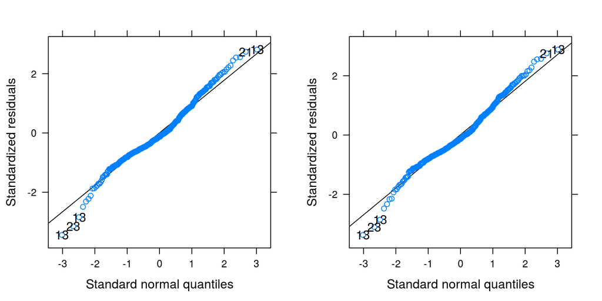

```r
qqp_21 <- qqmath(m_con_lambert_a_1$full_model, id = 0.01, idLabels = as.character(drp_r_r1$P.s))
qqp_22 <- qqmath(m_con_lambert_a_3$full_model, id = 0.01, idLabels = as.character(drp_r_r1$P.s))
grid.arrange(qqp_21, qqp_22, ncol = 2)
```

Furthermore, neither model shows a significant effect of `Accepts` (z-transformed to `acc_z`).

```r
nice(m_con_lambert_a_1)
```

```
## Mixed Model Anova Table (Type 3 tests, KR-method)
##
## Model: consequentw ~ acc_z + (acc_z | P.s) + (Fit | Item)
## Data: drp_r_r1
##   Effect       df    F p.value
## 1  acc_z 1, 12.47 0.19     .67
## ---
## Signif. codes:  0 '***' 0.001 '**' 0.01 '*' 0.05 '+' 0.1 ' ' 1
```

```r
nice(m_con_lambert_a_3)
```

```
## Mixed Model Anova Table (Type 3 tests, KR-method)
##
## Model: consequentw ~ acc_z + (1 | P.s) + (1 | Item)
## Data: drp_r_r1
##   Effect        df    F p.value
## 1  acc_z 1, 364.06 0.20     .65
## ---
## Signif. codes:  0 '***' 0.001 '**' 0.01 '*' 0.05 '+' 0.1 ' ' 1
```

# Spillover

## With Fit (log-transformed RTs)

```r
m_fp_spill_f_1 <- mixed(log_spill ~ Fit + (Fit|P.s) + (Fit| Item), drp_r, progress = FALSE)
```

```
## Contrasts set to contr.sum for the following variables: Fit, P.s, Item
```

```r
summary(m_fp_spill_f_1)
```

```
## Linear mixed model fit by REML ['merModLmerTest']
## Formula: log_spill ~ Fit + (Fit | P.s) + (Fit | Item)
##    Data: drp_r
##
## REML criterion at convergence: 659.2
##
## Scaled residuals:
##     Min      1Q  Median      3Q     Max
## -4.9539 -0.2958  0.1582  0.5529  2.2875
##
## Random effects:
##  Groups   Name        Variance  Std.Dev. Corr
##  P.s      (Intercept) 6.545e-02 0.255832
##           Fit1        3.177e-03 0.056365 -1.00
##  Item     (Intercept) 3.274e-02 0.180933
##           Fit1        8.219e-05 0.009066 1.00
##  Residual             2.595e-01 0.509411
## Number of obs: 396, groups:  P.s, 24; Item, 17
##
## Fixed effects:
##             Estimate Std. Error t value
## (Intercept)  0.61370    0.07287   8.421
## Fit1         0.02193    0.02820   0.778
##
## Correlation of Fixed Effects:
##      (Intr)
## Fit1 -0.243
```

Due to the large correlation between the by-participants and by-item random-effects parameters we refit the model without the correlations.

```r
m_fp_spill_f_2 <- mixed(log_spill ~ Fit + (Fit||P.s) + (Fit||Item), drp_r, expand_re = TRUE, progress = FALSE)
```

```
## Contrasts set to contr.sum for the following variables: Fit, P.s, Item
```

```r
summary(m_fp_spill_f_2)
```

```
## Linear mixed model fit by REML ['merModLmerTest']
## Formula: log_spill ~ Fit + ((1 | P.s) + (0 + re1.Fit1 | P.s)) + ((1 |
##     Item) + (0 + re2.Fit1 | Item))
##    Data: drp_r
##
## REML criterion at convergence: 662.8
##
## Scaled residuals:
##     Min      1Q  Median      3Q     Max
## -4.9072 -0.3173  0.1433  0.5365  2.2887
##
## Random effects:
##  Groups   Name        Variance Std.Dev.
##  P.s      (Intercept) 0.06522  0.2554
##  P.s.1    re1.Fit1    0.00000  0.0000
##  Item     (Intercept) 0.03132  0.1770
##  Item.1   re2.Fit1    0.00000  0.0000
##  Residual             0.26325  0.5131
## Number of obs: 396, groups:  P.s, 24; Item, 17
##
## Fixed effects:
##             Estimate Std. Error t value
## (Intercept)  0.61263    0.07230   8.474
## Fit1         0.02266    0.02583   0.877
##
## Correlation of Fixed Effects:
##      (Intr)
## Fit1 0.004
```

Now both random slopes are estimated to be zero, we consequently refit the model without those parameters.

```r
m_fp_spill_f_3 <- mixed(log_spill ~ Fit + (1|P.s) + (1| Item), drp_r, progress = FALSE)
```

```
## Contrasts set to contr.sum for the following variables: Fit, P.s, Item
```

```r
summary(m_fp_spill_f_3)
```

```
## Linear mixed model fit by REML ['merModLmerTest']
## Formula: log_spill ~ Fit + (1 | P.s) + (1 | Item)
##    Data: drp_r
##
## REML criterion at convergence: 662.8
##
## Scaled residuals:
##     Min      1Q  Median      3Q     Max
## -4.9072 -0.3173  0.1433  0.5365  2.2887
##
## Random effects:
##  Groups   Name        Variance Std.Dev.
##  P.s      (Intercept) 0.06522  0.2554
##  Item     (Intercept) 0.03132  0.1770
##  Residual             0.26325  0.5131
## Number of obs: 396, groups:  P.s, 24; Item, 17
##
## Fixed effects:
##             Estimate Std. Error t value
## (Intercept)  0.61263    0.07230   8.474
## Fit1         0.02266    0.02583   0.877
##
## Correlation of Fixed Effects:
##      (Intr)
## Fit1 0.004
```

Again the final model appears to be the optimal model.

```r
anova(m_fp_spill_f_1, m_fp_spill_f_3)
```

```
## Data: drp_r
## Models:
## m_fp_spill_f_3: log_spill ~ Fit + (1 | P.s) + (1 | Item)
## m_fp_spill_f_1: log_spill ~ Fit + (Fit | P.s) + (Fit | Item)
##                Df    AIC    BIC  logLik deviance  Chisq Chi Df Pr(>Chisq)
## m_fp_spill_f_3  5 672.84 692.75 -331.42   662.84
## m_fp_spill_f_1  9 677.17 713.01 -329.59   659.17 3.6707      4     0.4524
```

The QQ-plot again shows a clear deviation from normality for fast responses.

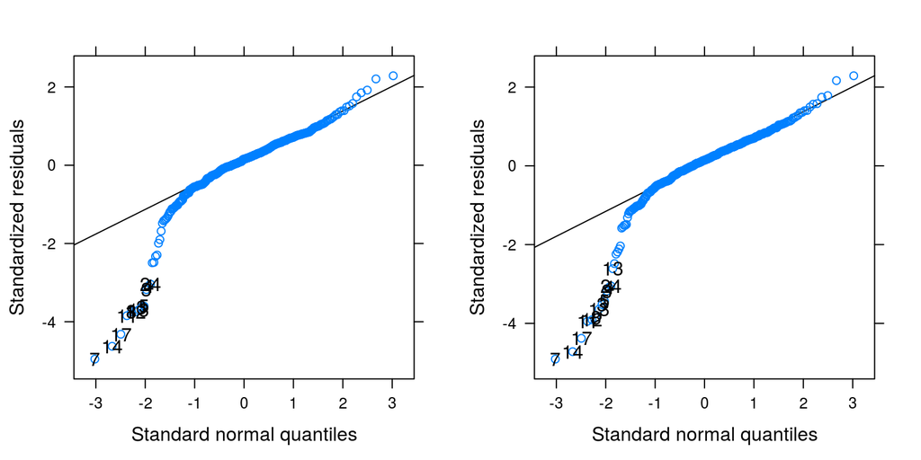

```r
qqp_m1 <- qqmath(m_fp_spill_f_1$full_model, id = 0.01, idLabels = as.character(drp_r$P.s))
qqp_m2 <- qqmath(m_fp_spill_f_3$full_model, id = 0.01, idLabels = as.character(drp_r$P.s))
grid.arrange(qqp_m1, qqp_m2, ncol = 2)
```

The effect of `Fit` is not significant.

```r
nice(m_fp_spill_f_1)
```

```
## Mixed Model Anova Table (Type 3 tests, KR-method)
##
## Model: log_spill ~ Fit + (Fit | P.s) + (Fit | Item)
## Data: drp_r
##   Effect       df    F p.value
## 1    Fit 1, 10.74 0.60     .45
## ---
## Signif. codes:  0 '***' 0.001 '**' 0.01 '*' 0.05 '+' 0.1 ' ' 1
```

```r
nice(m_fp_spill_f_3)
```

```
## Mixed Model Anova Table (Type 3 tests, KR-method)
##
## Model: log_spill ~ Fit + (1 | P.s) + (1 | Item)
## Data: drp_r
##   Effect        df    F p.value
## 1    Fit 1, 355.76 0.77     .38
## ---
## Signif. codes:  0 '***' 0.001 '**' 0.01 '*' 0.05 '+' 0.1 ' ' 1
```

## With Fit (Lambert-transformed RTs)

Due to the large misfit, we again try the Lambert transformation after removing 3 RTs we identified as outliers (based on preliminary analysis not reported here).

```r
out_spill <- (drp_r$P.s == "14" & drp_r$spillover < 0.5 ) |
  (drp_r$P.s == "23" & drp_r$spillover > 6.0 )
drp_r_r2 <- drp_r[!out_spill,]
drp_r_r2$spilloverw <- as.vector(LambertW::Gaussianize(drp_r_r2$spillover,
                                                        type = "h", method = "MLE"))
```

```r
m_fp_spill_a_1 <- mixed(spilloverw ~ Fit + (Fit|P.s) + (Fit| Item), drp_r_r2, progress = FALSE)
```

```
## Contrasts set to contr.sum for the following variables: Fit, P.s, Item
```

```r
summary(m_fp_spill_a_1)
```

```
## Linear mixed model fit by REML ['merModLmerTest']
## Formula: spilloverw ~ Fit + (Fit | P.s) + (Fit | Item)
##    Data: drp_r_r2
##
## REML criterion at convergence: 858.6
##
## Scaled residuals:
##     Min      1Q  Median      3Q     Max
## -3.2606 -0.5497 -0.0443  0.5980  3.0146
##
## Random effects:
##  Groups   Name        Variance  Std.Dev. Corr
##  P.s      (Intercept) 0.2665589 0.51629
##           Fit1        0.0011171 0.03342  -1.00
##  Item     (Intercept) 0.1216656 0.34881
##           Fit1        0.0002158 0.01469  1.00
##  Residual             0.4056225 0.63689
## Number of obs: 393, groups:  P.s, 24; Item, 17
##
## Fixed effects:
##             Estimate Std. Error t value
## (Intercept)  2.08444    0.13893  15.003
## Fit1         0.02205    0.03311   0.666
##
## Correlation of Fixed Effects:
##      (Intr)
## Fit1 -0.088
```

Due to the large correlation between the by-participants and by-item random-effects parameters we refit the model without the correlations.

```r
m_fp_spill_a_2 <- mixed(spilloverw ~ Fit + (Fit||P.s) + (Fit|| Item), drp_r_r2, progress = FALSE, expand_re = TRUE)
```

```
## Contrasts set to contr.sum for the following variables: Fit, P.s, Item
```

```r
summary(m_fp_spill_a_2)
```

```
## Linear mixed model fit by REML ['merModLmerTest']
## Formula: spilloverw ~ Fit + ((1 | P.s) + (0 + re1.Fit1 | P.s)) + ((1 |
##     Item) + (0 + re2.Fit1 | Item))
##    Data: drp_r_r2
##
## REML criterion at convergence: 859.6
##
## Scaled residuals:
##     Min      1Q  Median      3Q     Max
## -3.2423 -0.5265 -0.0539  0.6017  2.9554
##
## Random effects:
##  Groups   Name        Variance Std.Dev.
##  P.s      (Intercept) 0.2665   0.5163
##  P.s.1    re1.Fit1    0.0000   0.0000
##  Item     (Intercept) 0.1204   0.3470
##  Item.1   re2.Fit1    0.0000   0.0000
##  Residual             0.4071   0.6381
## Number of obs: 393, groups:  P.s, 24; Item, 17
##
## Fixed effects:
##             Estimate Std. Error t value
## (Intercept)  2.08366    0.13867   15.03
## Fit1         0.02257    0.03226    0.70
##
## Correlation of Fixed Effects:
##      (Intr)
## Fit1 0.003
```

Now both random slopes are estimated to be virtually zero, we consequently refit the model without those parameters.

```r
m_fp_spill_a_3 <- mixed(spilloverw ~ Fit + (1|P.s) + (1| Item), drp_r_r2, progress = FALSE)
```

```
## Contrasts set to contr.sum for the following variables: Fit, P.s, Item
```

```r
summary(m_fp_spill_a_3)
```

```
## Linear mixed model fit by REML ['merModLmerTest']
## Formula: spilloverw ~ Fit + (1 | P.s) + (1 | Item)
##    Data: drp_r_r2
##
## REML criterion at convergence: 859.6
##
## Scaled residuals:
##     Min      1Q  Median      3Q     Max
## -3.2423 -0.5265 -0.0539  0.6017  2.9554
##
## Random effects:
##  Groups   Name        Variance Std.Dev.
##  P.s      (Intercept) 0.2665   0.5163
##  Item     (Intercept) 0.1204   0.3470
##  Residual             0.4071   0.6381
## Number of obs: 393, groups:  P.s, 24; Item, 17
##
## Fixed effects:
##             Estimate Std. Error t value
## (Intercept)  2.08366    0.13867   15.03
## Fit1         0.02257    0.03226    0.70
##
## Correlation of Fixed Effects:
##      (Intr)
## Fit1 0.003
```

Again the final model appears to be the optimal model.

```r
anova(m_fp_spill_a_1, m_fp_spill_a_2, m_fp_spill_a_3)
```

```
## Data: drp_r_r2
## Models:
## m_fp_spill_a_3: spilloverw ~ Fit + (1 | P.s) + (1 | Item)
## m_fp_spill_a_2: spilloverw ~ Fit + ((1 | P.s) + (0 + re1.Fit1 | P.s)) + ((1 |
## m_fp_spill_a_2:     Item) + (0 + re2.Fit1 | Item))
## m_fp_spill_a_1: spilloverw ~ Fit + (Fit | P.s) + (Fit | Item)
##                Df    AIC    BIC  logLik deviance  Chisq Chi Df Pr(>Chisq)
## m_fp_spill_a_3  5 869.64 889.51 -429.82   859.64
## m_fp_spill_a_2  7 873.64 901.46 -429.82   859.64 0.0000      2     1.0000
## m_fp_spill_a_1  9 876.61 912.38 -429.31   858.61 1.0296      2     0.5976
```

The QQ-plot now only shows comparatively mild violations at the edges.

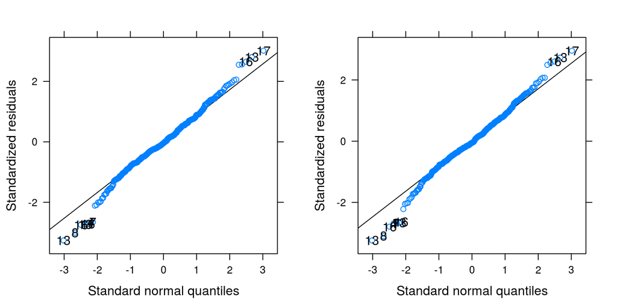

```r
qqp_m1 <- qqmath(m_fp_spill_a_1$full_model, id = 0.01, idLabels = as.character(drp_r_r2$P.s))
qqp_m2 <- qqmath(m_fp_spill_a_3$full_model, id = 0.01, idLabels = as.character(drp_r_r2$P.s))
grid.arrange(qqp_m1, qqp_m2, ncol = 2)
```

The effect of `Fit` remains not significant.

```r
nice(m_fp_spill_a_1)
```

```
## Mixed Model Anova Table (Type 3 tests, KR-method)
##
## Model: spilloverw ~ Fit + (Fit | P.s) + (Fit | Item)
## Data: drp_r_r2
##   Effect      df    F p.value
## 1    Fit 1, 9.20 0.44     .52
## ---
## Signif. codes:  0 '***' 0.001 '**' 0.01 '*' 0.05 '+' 0.1 ' ' 1
```

```r
nice(m_fp_spill_a_3)
```

```
## Mixed Model Anova Table (Type 3 tests, KR-method)
##
## Model: spilloverw ~ Fit + (1 | P.s) + (1 | Item)
## Data: drp_r_r2
##   Effect        df    F p.value
## 1    Fit 1, 352.38 0.49     .48
## ---
## Signif. codes:  0 '***' 0.001 '**' 0.01 '*' 0.05 '+' 0.1 ' ' 1
```

## With Accepts (log-transformed RTs and Accepts)

```r
m_fp_spill_al_1 <- mixed(log_spill ~ log_acc + (log_acc|P.s) + (Fit| Item),
                         drp_r, progress = FALSE)
```

```
## Contrasts set to contr.sum for the following variables: P.s, Fit, Item
```

```
## Numerical variables NOT centered on 0 (i.e., interpretation of all main effects might be difficult if in interactions): log_acc
```

```r
summary(m_fp_spill_al_1)
```

```
## Linear mixed model fit by REML ['merModLmerTest']
## Formula: log_spill ~ log_acc + (log_acc | P.s) + (Fit | Item)
##    Data: drp_r
##
## REML criterion at convergence: 648.2
##
## Scaled residuals:
##     Min      1Q  Median      3Q     Max
## -5.0197 -0.3019  0.1581  0.5701  2.4512
##
## Random effects:
##  Groups   Name        Variance  Std.Dev. Corr
##  P.s      (Intercept) 1.1308281 1.06340
##           log_acc     0.2908339 0.53929  -1.00
##  Item     (Intercept) 0.0355385 0.18852
##           Fit1        0.0001083 0.01041  1.00
##  Residual             0.2525511 0.50254
## Number of obs: 396, groups:  P.s, 24; Item, 17
##
## Fixed effects:
##             Estimate Std. Error t value
## (Intercept)   0.4251     0.3266   1.302
## log_acc       0.1252     0.1955   0.640
##
## Correlation of Fixed Effects:
##         (Intr)
## log_acc -0.978
```

This model has correlations at the boundary of the parameter space. We refit the model without the correlations.

```r
m_fp_spill_al_2 <- mixed(log_spill ~ log_acc + (log_acc||P.s) + (Fit|| Item),
                         drp_r, progress = FALSE, expand_re = TRUE)
```

```
## Contrasts set to contr.sum for the following variables: P.s, Fit, Item
```

```
## Numerical variables NOT centered on 0 (i.e., interpretation of all main effects might be difficult if in interactions): log_acc
```

```r
summary(m_fp_spill_al_2)
```

```
## Linear mixed model fit by REML ['merModLmerTest']
## Formula: log_spill ~ log_acc + ((1 | P.s) + (0 + re1.log_acc | P.s)) +
##     ((1 | Item) + (0 + re2.Fit1 | Item))
##    Data: drp_r
##
## REML criterion at convergence: 658.9
##
## Scaled residuals:
##     Min      1Q  Median      3Q     Max
## -4.9424 -0.3156  0.1496  0.5328  2.3789
##
## Random effects:
##  Groups   Name        Variance Std.Dev.
##  P.s      (Intercept) 0.06548  0.2559
##  P.s.1    re1.log_acc 0.00000  0.0000
##  Item     (Intercept) 0.03280  0.1811
##  Item.1   re2.Fit1    0.00000  0.0000
##  Residual             0.26263  0.5125
## Number of obs: 396, groups:  P.s, 24; Item, 17
##
## Fixed effects:
##             Estimate Std. Error t value
## (Intercept)   0.3659     0.2552   1.434
## log_acc       0.1646     0.1634   1.008
##
## Correlation of Fixed Effects:
##         (Intr)
## log_acc -0.958
```

The by-item and by-participant random slope is zero hence we refit the model without it.

```r
m_fp_spill_al_3 <- mixed(log_spill ~ log_acc + (1|P.s) + (1| Item),
                         drp_r, progress = FALSE, expand_re = FALSE)
```

```
## Contrasts set to contr.sum for the following variables: P.s, Item
```

```
## Numerical variables NOT centered on 0 (i.e., interpretation of all main effects might be difficult if in interactions): log_acc
```

```r
summary(m_fp_spill_al_3)
```

```
## Linear mixed model fit by REML ['merModLmerTest']
## Formula: log_spill ~ log_acc + (1 | P.s) + (1 | Item)
##    Data: drp_r
##
## REML criterion at convergence: 658.9
##
## Scaled residuals:
##     Min      1Q  Median      3Q     Max
## -4.9424 -0.3156  0.1496  0.5328  2.3789
##
## Random effects:
##  Groups   Name        Variance Std.Dev.
##  P.s      (Intercept) 0.06548  0.2559
##  Item     (Intercept) 0.03280  0.1811
##  Residual             0.26263  0.5125
## Number of obs: 396, groups:  P.s, 24; Item, 17
##
## Fixed effects:
##             Estimate Std. Error t value
## (Intercept)   0.3659     0.2552   1.434
## log_acc       0.1646     0.1634   1.008
##
## Correlation of Fixed Effects:
##         (Intr)
## log_acc -0.958
```

Overall the best model appears to be the first model, notwithstanding its apparently defective nature.

```r
anova(m_fp_spill_al_1,m_fp_spill_al_2, m_fp_spill_al_3)
```

```
## Data: drp_r
## Models:
## m_fp_spill_al_3: log_spill ~ log_acc + (1 | P.s) + (1 | Item)
## m_fp_spill_al_2: log_spill ~ log_acc + ((1 | P.s) + (0 + re1.log_acc | P.s)) +
## m_fp_spill_al_2:     ((1 | Item) + (0 + re2.Fit1 | Item))
## m_fp_spill_al_1: log_spill ~ log_acc + (log_acc | P.s) + (Fit | Item)
##                 Df    AIC    BIC  logLik deviance  Chisq Chi Df Pr(>Chisq)
## m_fp_spill_al_3  5 668.92 688.82 -329.46   658.92
## m_fp_spill_al_2  7 672.92 700.79 -329.46   658.92  0.000      2   1.000000
## m_fp_spill_al_1  9 666.18 702.01 -324.09   648.18 10.739      2   0.004656
##
## m_fp_spill_al_3
## m_fp_spill_al_2
## m_fp_spill_al_1 **
## ---
## Signif. codes:  0 '***' 0.001 '**' 0.01 '*' 0.05 '.' 0.1 ' ' 1
```

The QQ-plot of both models again shows massive departure from normality for the small RTs.

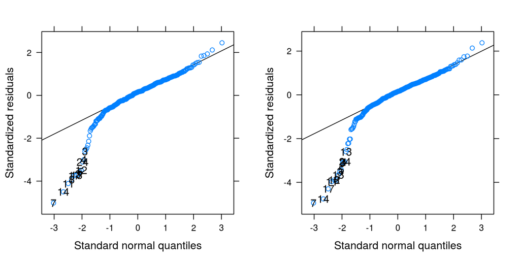

```r
qqp_m1 <- qqmath(m_fp_spill_al_1$full_model, id = 0.01, idLabels = as.character(drp_r$P.s))
qqp_m2 <- qqmath(m_fp_spill_al_3$full_model, id = 0.01, idLabels = as.character(drp_r$P.s))
grid.arrange(qqp_m1, qqp_m2, ncol = 2)
```

The effect of `log_acc` is not significant.

```r
nice(m_fp_spill_al_1)
```

```
## Mixed Model Anova Table (Type 3 tests, KR-method)
##
## Model: log_spill ~ log_acc + (log_acc | P.s) + (Fit | Item)
## Data: drp_r
##    Effect       df    F p.value
## 1 log_acc 1, 17.54 0.38     .55
## ---
## Signif. codes:  0 '***' 0.001 '**' 0.01 '*' 0.05 '+' 0.1 ' ' 1
```

```r
nice(m_fp_spill_al_3)
```

```
## Mixed Model Anova Table (Type 3 tests, KR-method)
##
## Model: log_spill ~ log_acc + (1 | P.s) + (1 | Item)
## Data: drp_r
##    Effect        df    F p.value
## 1 log_acc 1, 326.55 0.99     .32
## ---
## Signif. codes:  0 '***' 0.001 '**' 0.01 '*' 0.05 '+' 0.1 ' ' 1
```

### With Accepts (log-transformed RTs)

```r
m_fp_spill_a_1 <- mixed(log_spill ~ acc_z + (acc_z|P.s) + (Fit| Item), drp_r, progress = FALSE)
```

```
## Contrasts set to contr.sum for the following variables: P.s, Fit, Item
```

```r
summary(m_fp_spill_a_1)
```

```
## Linear mixed model fit by REML ['merModLmerTest']
## Formula: log_spill ~ acc_z + (acc_z | P.s) + (Fit | Item)
##    Data: drp_r
##
## REML criterion at convergence: 652.9
##
## Scaled residuals:
##     Min      1Q  Median      3Q     Max
## -5.0061 -0.2862  0.1525  0.5634  2.4729
##
## Random effects:
##  Groups   Name        Variance  Std.Dev. Corr
##  P.s      (Intercept) 0.0652248 0.25539
##           acc_z       0.0085019 0.09221  -1.00
##  Item     (Intercept) 0.0353376 0.18798
##           Fit1        0.0001198 0.01094  1.00
##  Residual             0.2537492 0.50374
## Number of obs: 396, groups:  P.s, 24; Item, 17
##
## Fixed effects:
##             Estimate Std. Error t value
## (Intercept)  0.61161    0.07368   8.300
## acc_z        0.02143    0.03495   0.613
##
## Correlation of Fixed Effects:
##       (Intr)
## acc_z -0.337
```

Again we observe large correlations among the random-effects parameters and we refit the model without these correlations.

```r
m_fp_spill_a_2 <- mixed(log_spill ~ acc_z + (acc_z||P.s) + (Fit||Item), drp_r, expand_re = TRUE, progress = FALSE)
```

```
## Contrasts set to contr.sum for the following variables: P.s, Fit, Item
```

```r
summary(m_fp_spill_a_2)
```

```
## Linear mixed model fit by REML ['merModLmerTest']
## Formula: log_spill ~ acc_z + ((1 | P.s) + (0 + re1.acc_z | P.s)) + ((1 |
##     Item) + (0 + re2.Fit1 | Item))
##    Data: drp_r
##
## REML criterion at convergence: 661.5
##
## Scaled residuals:
##     Min      1Q  Median      3Q     Max
## -4.7232 -0.3142  0.1515  0.5436  2.2549
##
## Random effects:
##  Groups   Name        Variance Std.Dev.
##  P.s      (Intercept) 0.065754 0.25643
##  P.s.1    re1.acc_z   0.005309 0.07286
##  Item     (Intercept) 0.033206 0.18223
##  Item.1   re2.Fit1    0.000000 0.00000
##  Residual             0.257232 0.50718
## Number of obs: 396, groups:  P.s, 24; Item, 17
##
## Fixed effects:
##             Estimate Std. Error t value
## (Intercept)  0.61268    0.07311    8.38
## acc_z        0.02759    0.03323    0.83
##
## Correlation of Fixed Effects:
##       (Intr)
## acc_z 0.002
```

The by-item random slope is now estimated at zero, we consequently refit the model without this parameters.

```r
m_fp_spill_a_3 <- mixed(log_spill ~ acc_z + (acc_z||P.s) + (1| Item), drp_r, expand_re = TRUE, progress = FALSE)
```

```
## Contrasts set to contr.sum for the following variables: P.s, Item
```

```r
summary(m_fp_spill_a_3)
```

```
## Linear mixed model fit by REML ['merModLmerTest']
## Formula: log_spill ~ acc_z + ((1 | P.s) + (0 + re1.acc_z | P.s)) + (1 |
##     Item)
##    Data: drp_r
##
## REML criterion at convergence: 661.5
##
## Scaled residuals:
##     Min      1Q  Median      3Q     Max
## -4.7232 -0.3142  0.1515  0.5436  2.2549
##
## Random effects:
##  Groups   Name        Variance Std.Dev.
##  P.s      (Intercept) 0.065754 0.25643
##  P.s.1    re1.acc_z   0.005309 0.07286
##  Item     (Intercept) 0.033206 0.18223
##  Residual             0.257232 0.50718
## Number of obs: 396, groups:  P.s, 24; Item, 17
##
## Fixed effects:
##             Estimate Std. Error t value
## (Intercept)  0.61268    0.07311    8.38
## acc_z        0.02759    0.03323    0.83
##
## Correlation of Fixed Effects:
##       (Intr)
## acc_z 0.002
```

Again, removing the correlation strangely leads to a considerable drop in fit.

```r
anova(m_fp_spill_a_1, m_fp_spill_a_2, m_fp_spill_a_3)
```

```
## Data: drp_r
## Models:
## m_fp_spill_a_3: log_spill ~ acc_z + ((1 | P.s) + (0 + re1.acc_z | P.s)) + (1 |
## m_fp_spill_a_3:     Item)
## m_fp_spill_a_2: log_spill ~ acc_z + ((1 | P.s) + (0 + re1.acc_z | P.s)) + ((1 |
## m_fp_spill_a_2:     Item) + (0 + re2.Fit1 | Item))
## m_fp_spill_a_1: log_spill ~ acc_z + (acc_z | P.s) + (Fit | Item)
##                Df    AIC    BIC  logLik deviance  Chisq Chi Df Pr(>Chisq)
## m_fp_spill_a_3  6 673.45 697.34 -330.73   661.45
## m_fp_spill_a_2  7 675.45 703.32 -330.73   661.45 0.0000      1    1.00000
## m_fp_spill_a_1  9 670.93 706.76 -326.46   652.93 8.5248      2    0.01409
##
## m_fp_spill_a_3
## m_fp_spill_a_2
## m_fp_spill_a_1 *
## ---
## Signif. codes:  0 '***' 0.001 '**' 0.01 '*' 0.05 '.' 0.1 ' ' 1
```

The QQ-plot of both models again shows strong departarue from normality for small RTs.

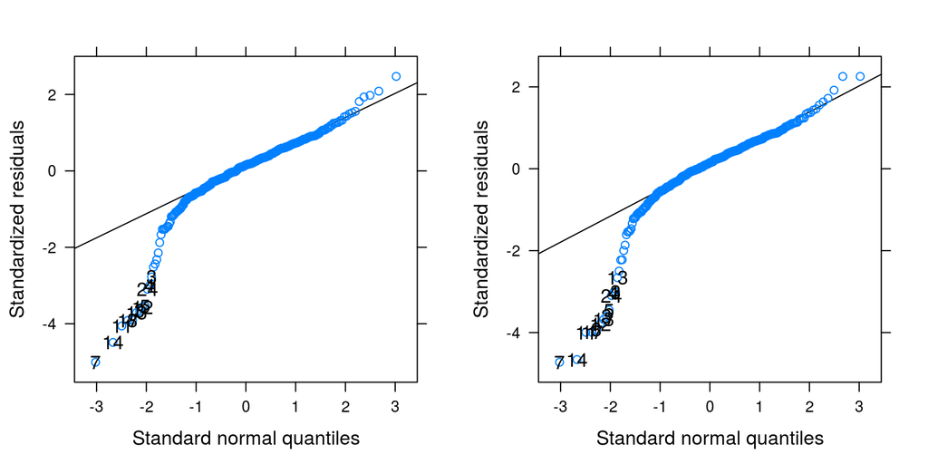

```r
qqp_m1 <- qqmath(m_fp_spill_a_1$full_model, id = 0.01, idLabels = as.character(drp_r$P.s))
qqp_m2 <- qqmath(m_fp_spill_a_3$full_model, id = 0.01, idLabels = as.character(drp_r$P.s))
grid.arrange(qqp_m1, qqp_m2, ncol = 2)
```

The effect of `acc_z` is not significant.

```r
nice(m_fp_spill_a_1)
```

```
## Mixed Model Anova Table (Type 3 tests, KR-method)
##
## Model: log_spill ~ acc_z + (acc_z | P.s) + (Fit | Item)
## Data: drp_r
##   Effect       df    F p.value
## 1  acc_z 1, 17.11 0.35     .56
## ---
## Signif. codes:  0 '***' 0.001 '**' 0.01 '*' 0.05 '+' 0.1 ' ' 1
```

```r
nice(m_fp_spill_a_3)
```

```
## Mixed Model Anova Table (Type 3 tests, KR-method)
##
## Model: log_spill ~ acc_z + (acc_z || P.s) + (1 | Item)
## Data: drp_r
##   Effect       df    F p.value
## 1  acc_z 1, 31.60 0.67     .42
## ---
## Signif. codes:  0 '***' 0.001 '**' 0.01 '*' 0.05 '+' 0.1 ' ' 1
```

## With Accept (Lambert-transformed RTs)

Due to the large misfit, we again try the Lambert transformation on the reduced data set.

```r
m_fp_spill_lambert_a_1 <- mixed(spilloverw ~ acc_z + (acc_z|P.s) + (Fit| Item), drp_r_r2, progress = FALSE)
```

```
## Contrasts set to contr.sum for the following variables: P.s, Fit, Item
```

```
## Numerical variables NOT centered on 0 (i.e., interpretation of all main effects might be difficult if in interactions): acc_z
```

```r
summary(m_fp_spill_lambert_a_1)
```

```
## Linear mixed model fit by REML ['merModLmerTest']
## Formula: spilloverw ~ acc_z + (acc_z | P.s) + (Fit | Item)
##    Data: drp_r_r2
##
## REML criterion at convergence: 857.1
##
## Scaled residuals:
##     Min      1Q  Median      3Q     Max
## -3.2630 -0.5557 -0.0315  0.5849  3.0430
##
## Random effects:
##  Groups   Name        Variance  Std.Dev. Corr
##  P.s      (Intercept) 0.2644383 0.51424
##           acc_z       0.0021677 0.04656  -1.00
##  Item     (Intercept) 0.1251616 0.35378
##           Fit1        0.0002333 0.01527  1.00
##  Residual             0.4040268 0.63563
## Number of obs: 393, groups:  P.s, 24; Item, 17
##
## Fixed effects:
##             Estimate Std. Error t value
## (Intercept)  2.08443    0.13921  14.973
## acc_z        0.03484    0.03984   0.875
##
## Correlation of Fixed Effects:
##       (Intr)
## acc_z -0.122
```

Due to the large correlations between the random-effects parameters we refit the model without the correlations.

```r
m_fp_spill_lambert_a_2 <- mixed(spilloverw ~ acc_z + (acc_z||P.s) + (Fit || Item), drp_r_r2, progress = FALSE, expand_re = TRUE)
```

```
## Contrasts set to contr.sum for the following variables: P.s, Fit, Item
```

```
## Numerical variables NOT centered on 0 (i.e., interpretation of all main effects might be difficult if in interactions): acc_z
```

```r
summary(m_fp_spill_lambert_a_2)
```

```
## Linear mixed model fit by REML ['merModLmerTest']
## Formula: spilloverw ~ acc_z + ((1 | P.s) + (0 + re1.acc_z | P.s)) + ((1 |
##     Item) + (0 + re2.Fit1 | Item))
##    Data: drp_r_r2
##
## REML criterion at convergence: 858.7
##
## Scaled residuals:
##     Min      1Q  Median      3Q     Max
## -3.2509 -0.5413 -0.0487  0.6026  2.9556
##
## Random effects:
##  Groups   Name        Variance Std.Dev.
##  P.s      (Intercept) 0.2678   0.5175
##  P.s.1    re1.acc_z   0.0000   0.0000
##  Item     (Intercept) 0.1232   0.3510
##  Item.1   re2.Fit1    0.0000   0.0000
##  Residual             0.4060   0.6372
## Number of obs: 393, groups:  P.s, 24; Item, 17
##
## Fixed effects:
##             Estimate Std. Error t value
## (Intercept)  2.08363    0.13944  14.943
## acc_z        0.03923    0.03860   1.016
##
## Correlation of Fixed Effects:
##       (Intr)
## acc_z 0.002
```

Now both random slopes are estimated to be virtually zero, we consequently refit the model without those parameters.

```r
m_fp_spill_lambert_a_3 <- mixed(spilloverw ~ acc_z + (1|P.s) + (1| Item), drp_r_r2, progress = FALSE, expand_re = FALSE)
```

```
## Contrasts set to contr.sum for the following variables: P.s, Item
```

```
## Numerical variables NOT centered on 0 (i.e., interpretation of all main effects might be difficult if in interactions): acc_z
```

```r
summary(m_fp_spill_lambert_a_3)
```

```
## Linear mixed model fit by REML ['merModLmerTest']
## Formula: spilloverw ~ acc_z + (1 | P.s) + (1 | Item)
##    Data: drp_r_r2
##
## REML criterion at convergence: 858.7
##
## Scaled residuals:
##     Min      1Q  Median      3Q     Max
## -3.2509 -0.5413 -0.0487  0.6026  2.9556
##
## Random effects:
##  Groups   Name        Variance Std.Dev.
##  P.s      (Intercept) 0.2678   0.5175
##  Item     (Intercept) 0.1232   0.3510
##  Residual             0.4060   0.6372
## Number of obs: 393, groups:  P.s, 24; Item, 17
##
## Fixed effects:
##             Estimate Std. Error t value
## (Intercept)  2.08363    0.13944  14.943
## acc_z        0.03923    0.03860   1.016
##
## Correlation of Fixed Effects:
##       (Intr)
## acc_z 0.002
```

This time the final model appears to be the optimal model.

```r
anova(m_fp_spill_lambert_a_1, m_fp_spill_lambert_a_2, m_fp_spill_lambert_a_3)
```

```
## Data: drp_r_r2
## Models:
## m_fp_spill_lambert_a_3: spilloverw ~ acc_z + (1 | P.s) + (1 | Item)
## m_fp_spill_lambert_a_2: spilloverw ~ acc_z + ((1 | P.s) + (0 + re1.acc_z | P.s)) + ((1 |
## m_fp_spill_lambert_a_2:     Item) + (0 + re2.Fit1 | Item))
## m_fp_spill_lambert_a_1: spilloverw ~ acc_z + (acc_z | P.s) + (Fit | Item)
##                        Df    AIC    BIC  logLik deviance  Chisq Chi Df
## m_fp_spill_lambert_a_3  5 868.74 888.61 -429.37   858.74
## m_fp_spill_lambert_a_2  7 872.74 900.56 -429.37   858.74 0.0000      2
## m_fp_spill_lambert_a_1  9 875.13 910.90 -428.57   857.13 1.6093      2
##                        Pr(>Chisq)
## m_fp_spill_lambert_a_3
## m_fp_spill_lambert_a_2     1.0000
## m_fp_spill_lambert_a_1     0.4472
```

The QQ-plot now only shows comparatively mild violations at the edges. However, for the low RTs they still appear to large.

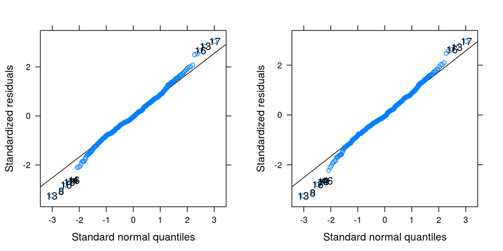

```r
qqp_m1 <- qqmath(m_fp_spill_lambert_a_1$full_model, id = 0.01, idLabels = as.character(drp_r_r2$P.s))
qqp_m2 <- qqmath(m_fp_spill_lambert_a_3$full_model, id = 0.01, idLabels = as.character(drp_r_r2$P.s))
grid.arrange(qqp_m1, qqp_m2, ncol = 2)
```

```r
nice(m_fp_spill_lambert_a_1)
```

```
## Mixed Model Anova Table (Type 3 tests, KR-method)
##
## Model: spilloverw ~ acc_z + (acc_z | P.s) + (Fit | Item)
## Data: drp_r_r2
##   Effect       df    F p.value
## 1  acc_z 1, 13.10 0.71     .41
## ---
## Signif. codes:  0 '***' 0.001 '**' 0.01 '*' 0.05 '+' 0.1 ' ' 1
```

```r
nice(m_fp_spill_lambert_a_3)
```

```
## Mixed Model Anova Table (Type 3 tests, KR-method)
##
## Model: spilloverw ~ acc_z + (1 | P.s) + (1 | Item)
## Data: drp_r_r2
##   Effect        df    F p.value
## 1  acc_z 1, 365.98 1.02     .31
## ---
## Signif. codes:  0 '***' 0.001 '**' 0.01 '*' 0.05 '+' 0.1 ' ' 1
```